# Лабораторная работа №4-E «ЗАХВАТ СЕРВЕРА БАЗЫ ДАННЫХ»

## Bruteforce пароля

Для получения доступа к машине воспользуемся подключением MySQL по полученным учетным данным. Подключение выполняется с атакующей машины kali, для подключения используется proxychains

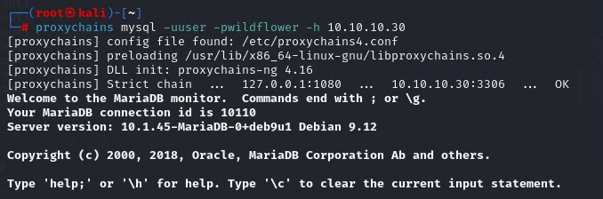

Рисунок 31: Подключение к MySQL

Для получения флага необходимо вывести таблицы БД «Flag»

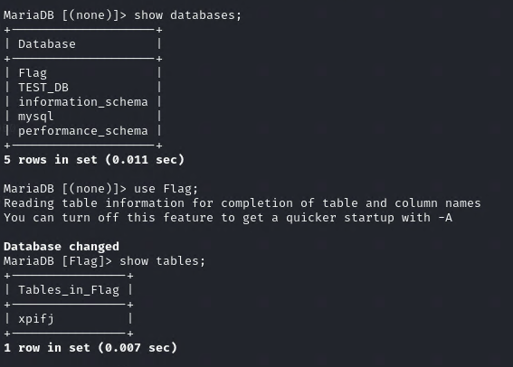

## Результат

После получения флага необходимо было ввести его в соответствующее поле на сайте платформы, после чего мы получим сообщение о том, что основная задача выполнена. Далее заполняем отчет по атаке на ресурс.

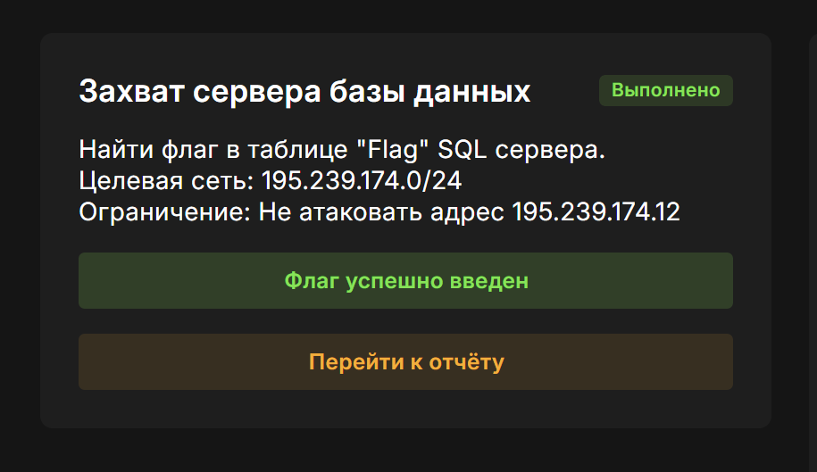

Рисунок 33: Отправка флага

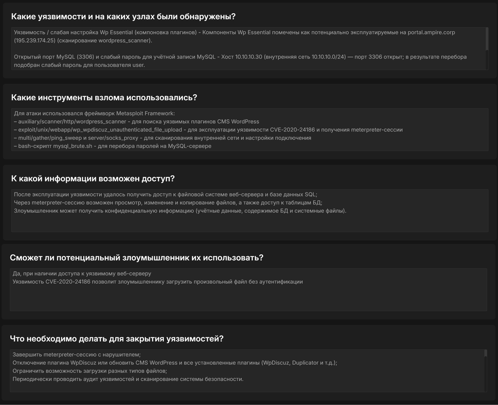

Рисунок 34: Заполнение отчета

## Выводы

В ходе лабораторной работы были успешно получены meterpreter-сессия и доступ к флагу, а также прописан отчет с целью закрытия найденных уязвимостей в будущем.

Спасибо за внимание!